# CS542 Common Task

# Dylan Tamayo

## Week 1: Manual Prediction

Temperature forecasts from four sources were used to make manual predictions for each city:

- Apple Weather app
- Google Weather forecast (ex. https://www.google.com/search?q=weather+belvedere+castle)
- The Weather Channel (https://www.weather.com)
- Accuweather (https://www.accuweather.com/)

Forecasted maximum temperature from each source for each city was recorded around 10 AM; forecasted temperatures were then averaged and rounded to the nearest integer to determine the corresponding Kalshi market.

## Week 2: Data Collection and Model Training

### Data Collection

| Information | Source | Type | Documentation Link | Notes |
| --- | --- | --- | --- | --- |
| Historical | Open-Meteo | API | https://open-meteo.com/en/docs/ |  |
| Historical | Meteostat | Python module | https://dev.meteostat.net/python/ |  |
| Recent | National Weather Service | Web scraping | https://forecast.weather.gov/product.php?site=OKX&issuedby=NYC&product=CLI https://forecast.weather.gov/product.php?site=EWX&issuedby=AUS&product=CLI https://forecast.weather.gov/product.php?site=LOT&… | Daily Climate Report |
| Forecast | AccuWeather | API | https://developer.accuweather.com/apis | 5-day forecast |
| Forecast | National Weather Service | API | https://www.weather.gov/documentation/services-web-api | 12-day forecast |
| Forecast | Visual-Crossing | API | https://www.visualcrossing.com/resources/documentation/weather-api/weather-api-documentation/ | 15-day forecast |

As non-web scraping data sources required latitude and longitude to retrieve weather information, coordinates were retrieved from the following locations via Apple maps:

| New York | Austin | Chicago | Miami |
| --- | --- | --- | --- |
| Belvedere Castle 79th St Transverse New York, NY 10028 | Austin-Bergstrom International Airport 3600 Presidential Blvd Austin, TX 78719 | Chicago Midway International Airport 5700 S Cicero Ave Chicago, IL 60638 | National Weather Service 11691 SW 17th St Miami, FL 33165 |

Data collection is as follows:

- On a given day (ex. 3/25/2024), historical data was retrieved from five years (3/25/2019) until the day prior (3/24/2024).
- The recent climatological reports which determine Kalshi market outcomes were scraped from the NWS website.
- Forecasts for upcoming days were retrieved. Files for each source are saved in that day's directory (2024.03.25) for each city.

To combine all six sources into one dataset consisting of date and maximum temperature, dates were adjusted into YYYY-MM-DD format, and then temperatures were averaged across dates for all sources.

### Model Training

Several machine learning models were tested to forecast weather, including transformers, RNN, linear regression, random forest and gradient boosting regression algorithm.

Attempted manipulations of the data included predicting on year, month, and date as separate features instead of one feature, as well as removing the forecasted temperature of the predicted day from the dataset.

Ultimately, gradient boosting was used to predict weather, providing a balance between low MSE, computational resource usage, and accuracy to other weather forecasts. Forecasts were made using year, month, and date as separate input features, with no other manipulations to the data.

## Week 3: Automated Prediction

Using the Kalshi API starter code, the appropriate market was selected according to the predicted forecast for each city. One Yes contract with a limit price of $0.99 was selected and set to expire at market close.

## Results

### Historical Data Comparison

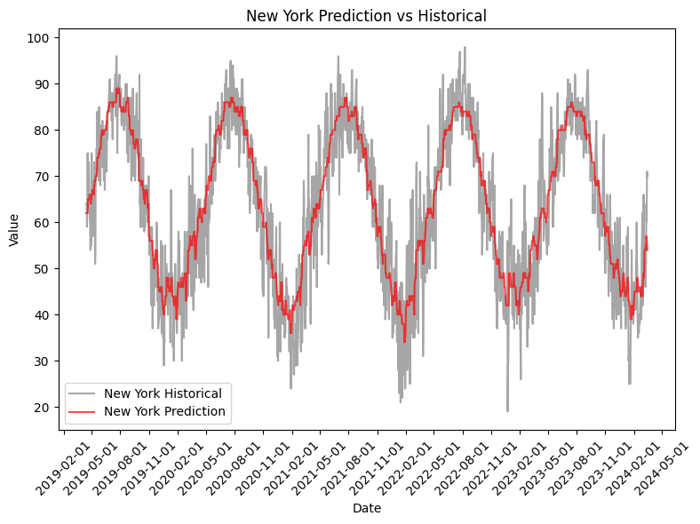

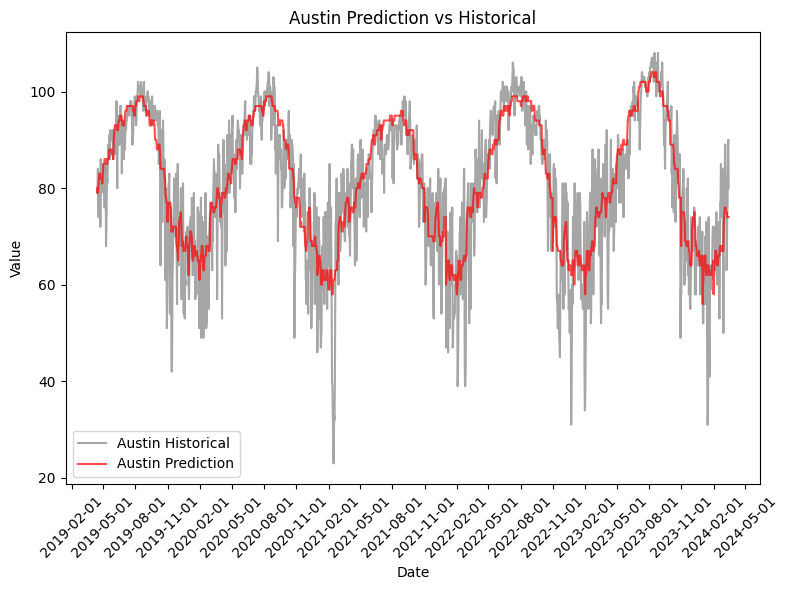

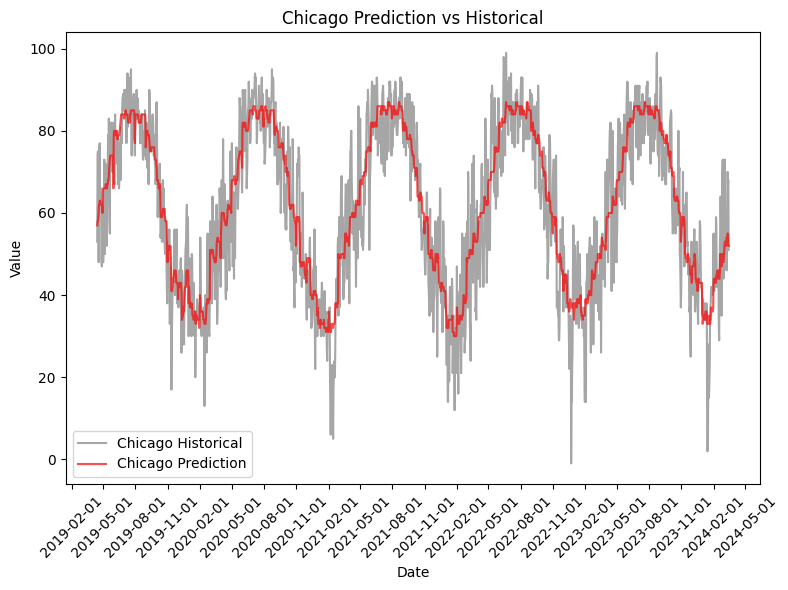

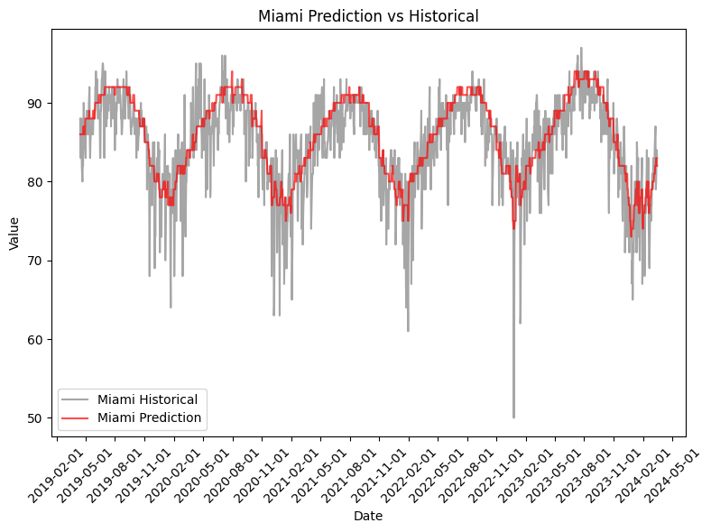

```python
import os
import pandas as pd
import matplotlib.pyplot as plt
from matplotlib.dates import DateFormatter, MonthLocator

path = os.getcwd()
df = pd.read_csv(f'{path}/historical_predictions.csv')

# Convert the 'Prediction Date' column to datetime format
df['Prediction Date'] = pd.to_datetime(df['Prediction Date'])

# Plot Prediction vs Historical for each city
cities = ['New York', 'Austin', 'Chicago', 'Miami']
for city in cities:
    plt.figure(figsize=(8, 6))
    plt.plot(df['Prediction Date'], df[f'{city}_Historical'], label=f'{city} Historical', color='gray', alpha=0.7)
    plt.plot(df['Prediction Date'], df[f'{city}_Prediction'], label=f'{city} Prediction', color='red', alpha=0.7)
    plt.xlabel('Date')
    plt.ylabel('Value')
    plt.title(f'{city} Prediction vs Historical')
    plt.legend()

    # Set x-axis ticks every 6 months
    plt.gca().xaxis.set_major_locator(MonthLocator(interval=3))
    plt.gca().xaxis.set_major_formatter(DateFormatter('%Y-%m-%d'))

    plt.xticks(rotation=45)
    plt.tight_layout()
    plt.show()
```

```python
from sklearn.metrics import mean_squared_error
from math import sqrt

cities = ['New York', 'Austin', 'Chicago', 'Miami']

# Calculate temp range for each city
print('City Maximum Temperature Range')
for city in cities:
    min_temp = df[f'{city}_Historical'].min()
    max_temp = df[f'{city}_Historical'].max()
    temp_range = max_temp - min_temp
    print(f'{city} - Min Temp: {min_temp}, Max Temp: {max_temp}, Temp Range: {temp_range}')
print()

# Calculate MSE and RMSE for each city
print('Historical vs. Predicted Error')
for city in cities:
    mse = mean_squared_error(df[f'{city}_Historical'], df[f'{city}_Prediction'])
    rmse = sqrt(mse)
    print(f'{city} - MSE: {round(mse, 3)}, RMSE: {round(rmse, 3)}')
```

```
City Maximum Temperature Range
New York - Min Temp: 19, Max Temp: 98, Temp Range: 79
Austin - Min Temp: 23, Max Temp: 108, Temp Range: 85
Chicago - Min Temp: -1, Max Temp: 99, Temp Range: 100
Miami - Min Temp: 50, Max Temp: 97, Temp Range: 47

Historical vs. Predicted Error
New York - MSE: 49.055, RMSE: 7.004
Austin - MSE: 57.034, RMSE: 7.552
Chicago - MSE: 75.997, RMSE: 8.718
Miami - MSE: 12.279, RMSE: 3.504
```

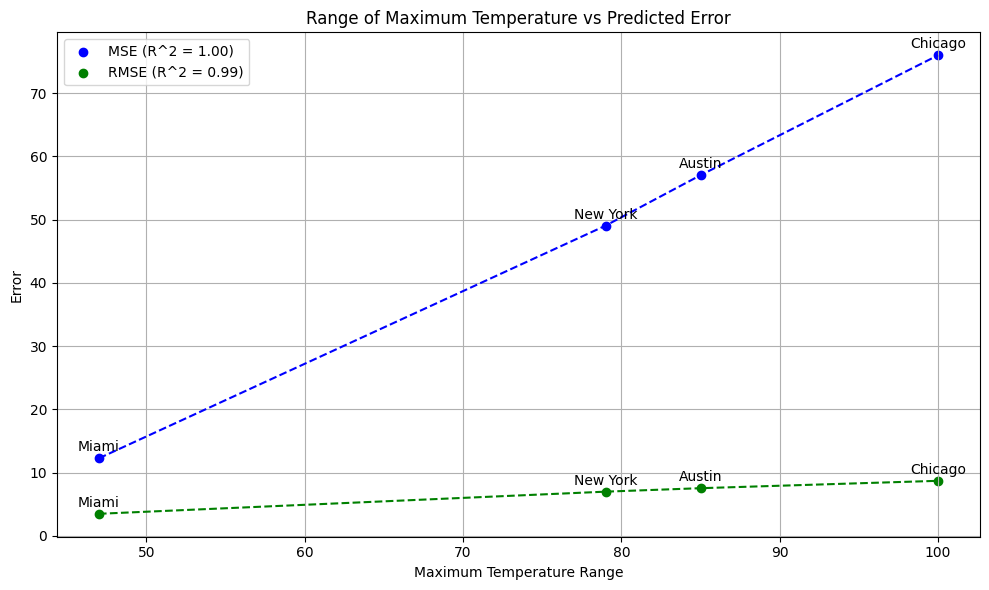

```python
import numpy as np
from sklearn.metrics import r2_score

cities = ['New York', 'Austin', 'Chicago', 'Miami']
temp_range = [79, 85, 100, 47]
mse = [49.055, 57.034, 75.997, 12.279]
rmse = [7.004, 7.552, 8.718, 3.504]

# Sort lists by temp_range
temp_range_sorted, mse_sorted, rmse_sorted, cities_sorted = zip(*sorted(zip(temp_range, mse, rmse, cities)))

# Calculate R-squared values for linearity
def calculate_r2_linearity(x, y):
    slope, intercept = np.polyfit(x, y, 1)
    y_pred = slope * np.array(x) + intercept
    r2 = r2_score(y, y_pred)
    return r2

r2_mse_sorted = calculate_r2_linearity(temp_range_sorted, mse_sorted)
r2_rmse_sorted = calculate_r2_linearity(temp_range_sorted, rmse_sorted)

# Plot MSE and RMSE vs Temp Range
plt.figure(figsize=(10, 6))

plt.scatter(temp_range_sorted, mse_sorted, color='blue', label=f'MSE (R^2 = {r2_mse_sorted:.2f})')
plt.plot(temp_range_sorted, mse_sorted, color='blue', linestyle='--')

plt.scatter(temp_range_sorted, rmse_sorted, color='green', label=f'RMSE (R^2 = {r2_rmse_sorted:.2f})')
plt.plot(temp_range_sorted, rmse_sorted, color='green', linestyle='--')

# Annotate points with city labels
for i, city in enumerate(cities_sorted):
    plt.annotate(city, (temp_range_sorted[i], mse_sorted[i]), textcoords='offset points', xytext=(0,5), ha='center')
    plt.annotate(city, (temp_range_sorted[i], rmse_sorted[i]), textcoords='offset points', xytext=(0,5), ha='center')

plt.xlabel('Maximum Temperature Range')
plt.ylabel('Error')
plt.title('Range of Maximum Temperature vs Predicted Error')
plt.legend()
plt.grid(True)
plt.tight_layout()
plt.show()
```

The maximum temperature range for each city, taken as an indicator of temperature variability, scales linearly with the error MSE for each city. Based off these results, it is predicted that the gradient boosting model will perform the worst when predicting temperature for Chicago, and the best when predicting for Miami.

### Weeks 1–3 Comparison

#### Results per City per Week

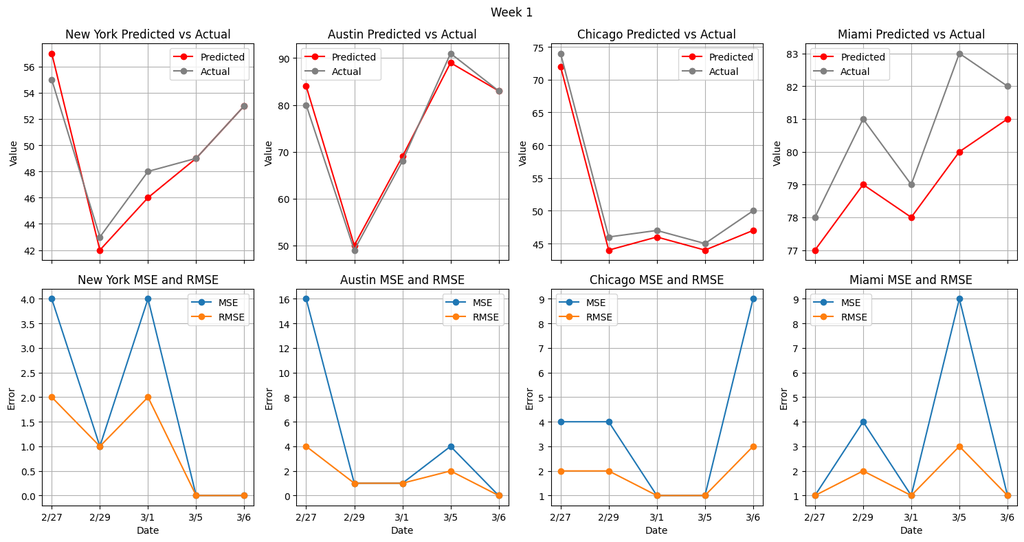

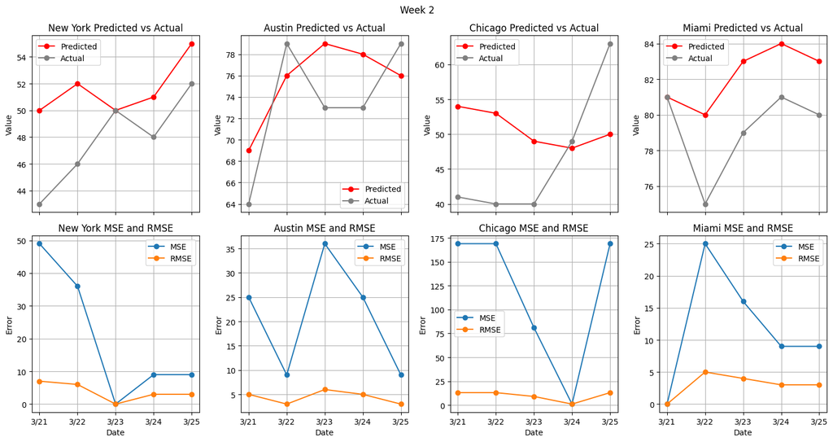

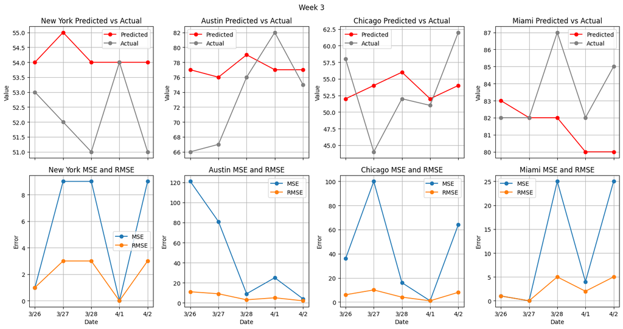

```python
# Load the CSV file
path = os.getcwd()
df = pd.read_csv(f'{path}/common_task_results.csv')

# Group data by week
grouped = df.groupby('Week')

# Plot Predicted vs Actual MSE and RMSE for each city grouped by week
cities = ['New York', 'Austin', 'Chicago', 'Miami']
for week, group_data in grouped:
    fig, axs = plt.subplots(nrows=2, ncols=len(cities), figsize=(15, 8), sharex=True)

    for idx, city in enumerate(cities):
        city_data = group_data[group_data['City'] == city]

        # Plot Predicted vs Actual
        axs[0, idx].plot(city_data['Date'], city_data['Predicted'], marker='o', linestyle='-', color='red', label='Predicted')
        axs[0, idx].plot(city_data['Date'], city_data['Actual'], marker='o', linestyle='-', color='gray', label='Actual')
        axs[0, idx].set_title(f'{city} Predicted vs Actual')
        axs[0, idx].set_ylabel('Value')
        axs[0, idx].legend()
        axs[0, idx].grid(True)

        # Plot MSE and RMSE
        axs[1, idx].plot(city_data['Date'], city_data['MSE'], marker='o', linestyle='-', label='MSE')
        axs[1, idx].plot(city_data['Date'], city_data['RMSE'], marker='o', linestyle='-', label='RMSE')
        axs[1, idx].set_title(f'{city} MSE and RMSE')
        axs[1, idx].set_xlabel('Date')
        axs[1, idx].set_ylabel('Error')
        axs[1, idx].legend()
        axs[1, idx].grid(True)

    plt.suptitle(f'Week {week}')
    plt.tight_layout()
    plt.show()
```

#### Results per City Across All Weeks

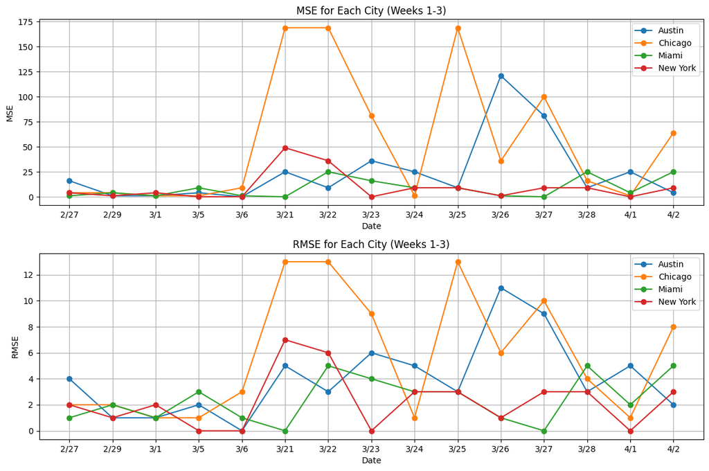

```python
# Group filtered data by city
grouped = df.groupby('City')

# Create subplots for MSE and RMSE for each city across weeks 1-3
plt.figure(figsize=(12, 8))

# Plot MSE for each city
plt.subplot(2, 1, 1)
for city, group_data in grouped:
    plt.plot(group_data['Date'], group_data['MSE'], marker='o', label=f'{city}')

plt.xlabel('Date')
plt.ylabel('MSE')
plt.title('MSE for Each City (Weeks 1-3)')
plt.legend()
plt.grid(True)

# Plot RMSE for each city
plt.subplot(2, 1, 2)
for city, group_data in grouped:
    plt.plot(group_data['Date'], group_data['RMSE'], marker='o', label=f'{city}')

plt.xlabel('Date')
plt.ylabel('RMSE')
plt.title('RMSE for Each City (Weeks 1-3)')
plt.legend()
plt.grid(True)

plt.tight_layout()
plt.show()
```

```python
# Group by Week and City, then sum MSE and RMSE
metrics_per_week_city = df.groupby(['Week', 'City']).agg({'MSE': 'mean', 'RMSE': 'mean'}).reset_index()
metrics_per_week_city.rename(columns={'MSE': 'Mean MSE', 'RMSE': 'Mean RMSE'}, inplace=True)
metrics_per_week_city.sort_values(by='City', inplace=True)

print(metrics_per_week_city)
```

```
    Week      City  Mean MSE  Mean RMSE
0      1    Austin       4.4        1.6
4      2    Austin      20.8        4.4
8      3    Austin      48.0        6.0
1      1   Chicago       3.8        1.8
5      2   Chicago     117.8        9.8
9      3   Chicago      43.4        5.8
2      1     Miami       3.2        1.6
6      2     Miami      11.8        3.0
10     3     Miami      11.0        2.6
3      1  New York       1.8        1.0
7      2  New York      20.6        3.8
11     3  New York       5.6        2.0
```

In contrast to the predicted historical data, however, temperature predictions for New York outperformed Miami in Week 3.

## Conclusions

Given the variability and randomness of day-to-day weather, predicting the forecast with perfect accuracy is an unlikely task. However, it is possible to achieve close results, as demonstrated by the forecast predictions used in Week 1 matching the trend of the actual weather. While the gradient boosted model achieved some accurate predictions, trends as predicted by the model often did not match actual. Extending the performance of the model beyond the two five-day periods of Weeks 2 and 3, would likely provide results that vary as heavily as the weather does.

Possible future directions for adjusting the model include:

- Increasing or decreasing the amount of historical data used
- Combining datasets for each city into one
- Weighting recent days more heavily for forecasting weather
- Adding features that may contribute to the maximum temperature such as humidity, precipitation, wind speed, daytime length

Alternative machine learning models such as transformers and RNNs may perform better than gradient boosting if additional features are added, if they are better able to identify more complex relationships.